# Data 607 Assignment 2

#### *Rathish Parayil Sasidharan*

## Overview

Created a survey to rate six movies **GREENLAND,THE CROODS: A NEW AGE,MULAN,SUMMERLAND,GREYHOUND,THE GENTLEMEN**  
with rating Excellent (5),Good (4),Not Bad(3), Bad(2),Awful(1) and collected the survey response.

[Please find the survey](https://www.surveymonkey.com/r/F82FVCV)

High level tasks performed as part of this assignment

1. Created a survey in surveymonkey and collected the response
2. Created AWS RDS instance and configured it to access using public url
3. Created 2 normalized tables,one for movie and other for movie rating
4. Inserted the response data into database table using a script
5. In order to protect the data ,created a readonly user account on the db
6. Read the data from database from the R Markup
7. Eliminated N/A data
8. Data transformation and Visualization

## Prerequisites

Load required packages

```r
#install.packages("RMySQL")
library("RMySQL")
library("dplyr")
library("ggplot2")
library("tidyr")
#library("config")
```

## Loading the dataframe from the Data base

```r
# Create a connection Object to MySQL database.

#password can also be read as a user input by knit with parameter option
#or can also be read from a config file(yaml)
#dw <- config::get("applicationdb")
#print(dw$server)
#print(dw$uid)
#print(dw$pwd)
#mysqlconnection = dbConnect(MySQL(), user = dw$uid, password = dw$pwd, dbname = 'database_name',
 #  host = dw$server)



mysqlconnection = dbConnect(MySQL(), user = 'readOnly', password = 'welcome', dbname = 'database_name',
   host = 'rassnw2.c4h7w2meulft.us-east-1.rds.amazonaws.com')

# List the tables available in this database.
 #dbListTables(mysqlconnection)

 # Query the movie rating tables to get all rating and associated movies.
 result = dbSendQuery(mysqlconnection, "select mr.id,mv.movie_name,mr.rating from movie_rating mr join movie mv on mr.movie_id = mv.movie_id")

# Store the result in a R data frame object. n = 30 is used to fetch first 30 rows.
employeedata = fetch(result, n = 30)
print(employeedata)
```

```
##    id            movie_name rating
## 1   1             GREENLAND      5
## 2   2 THE CROODS: A NEW AGE      3
## 3   3                 MULAN      1
## 4   4            SUMMERLAND      2
## 5   5             GREYHOUND      5
## 6   6         THE GENTLEMEN     NA
## 7   7             GREENLAND      2
## 8   8 THE CROODS: A NEW AGE      4
## 9   9                 MULAN      3
## 10 10            SUMMERLAND      5
## 11 11             GREYHOUND      1
## 12 12         THE GENTLEMEN     NA
## 13 13             GREENLAND      5
## 14 14 THE CROODS: A NEW AGE      5
```

[output cut: 16 more lines]

### Clean up the data

```r
employee_valid_data <- employeedata %>% drop_na()

# Conver the ratings into a Readable Text
 employee_valid_data <- mutate(employee_valid_data,review = case_when(rating == 5 ~'Excellent',rating == 4 ~'Good',rating == 3 ~'Not Bad',rating == 2 ~'Bad',rating == 1 ~'Awful' ))

 print(employee_valid_data)
```

```
##    id            movie_name rating    review
## 1   1             GREENLAND      5 Excellent
## 2   2 THE CROODS: A NEW AGE      3   Not Bad
## 3   3                 MULAN      1     Awful
## 4   4            SUMMERLAND      2       Bad
## 5   5             GREYHOUND      5 Excellent
## 6   7             GREENLAND      2       Bad
## 7   8 THE CROODS: A NEW AGE      4      Good
## 8   9                 MULAN      3   Not Bad
## 9  10            SUMMERLAND      5 Excellent
## 10 11             GREYHOUND      1     Awful
## 11 13             GREENLAND      5 Excellent
## 12 14 THE CROODS: A NEW AGE      5 Excellent
## 13 16            SUMMERLAND      3   Not Bad
## 14 17             GREYHOUND      2       Bad
## 15 19             GREENLAND      4      Good
## 16 20 THE CROODS: A NEW AGE      3   Not Bad
## 17 21                 MULAN      3   Not Bad
## 18 23             GREYHOUND      2       Bad
## 19 24         THE GENTLEMEN      5 Excellent
## 20 25             GREENLAND      5 Excellent
## 21 26 THE CROODS: A NEW AGE      4      Good
## 22 28            SUMMERLAND      3   Not Bad
## 23 29             GREYHOUND      3   Not Bad
## 24 30         THE GENTLEMEN      4      Good
```

### Data visualization

How each movies are rated by the users ?  
Plot a graph with list of movies vs number of rating for each category

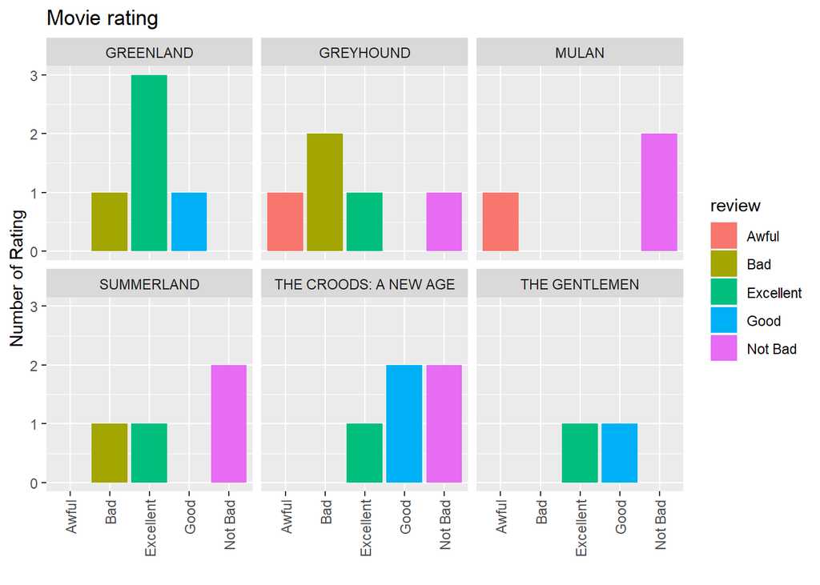

```r
ggplot(count(employee_valid_data,movie_name,review), aes(fill=review, y=n, x=review)) +
     geom_bar(position="dodge", stat="identity") +
     ggtitle("Movie rating") +
     facet_wrap(~movie_name)+xlab("")+ylab("Number of Rating") + theme(axis.text.x = element_text(angle = 90, vjust = 0.5, hjust=1))
```

### Conclusion

According to the survey result “Greenland” movie has got better rating